# Secondary analysis of CanCORS multi center cohort study

## Latent class analysis-identify the class membership for each patient by time to surgery

```
##   1   2
## 478 733
```

- 733 Patients are classified as early trt group, 478 patients are classified as late trt group

## Random Forest

### Find pairwise interactions between variables.

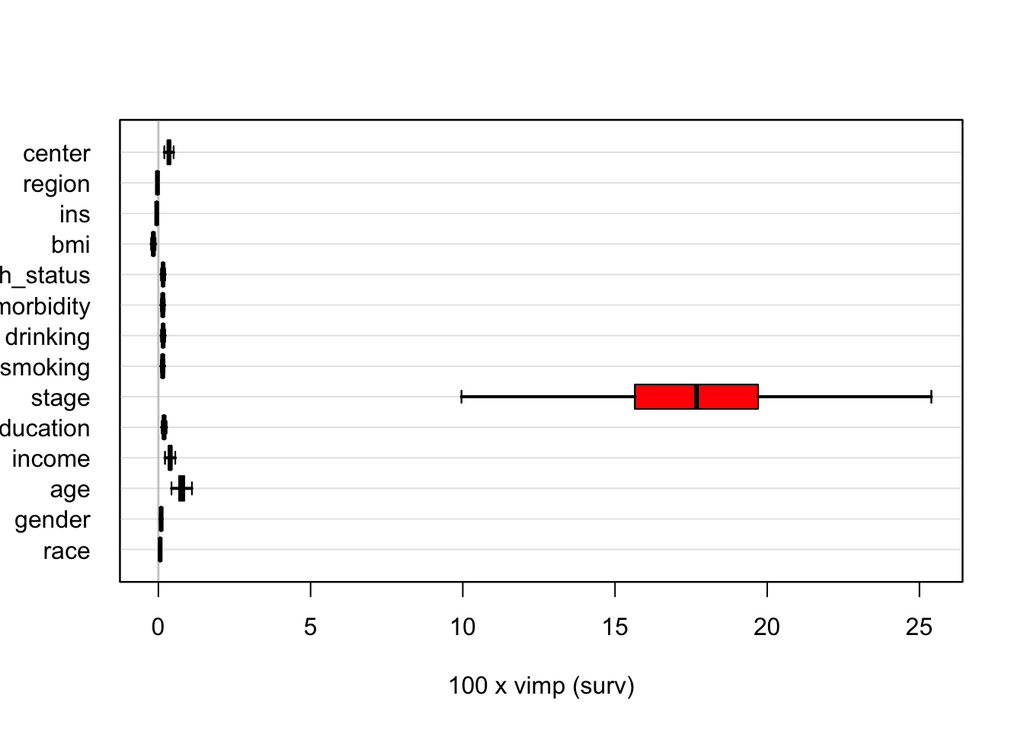

```r
par(mfrow=c(1,1))
plot(rf1.sub)
```

- cancer stage is the only significant factor in baseline model

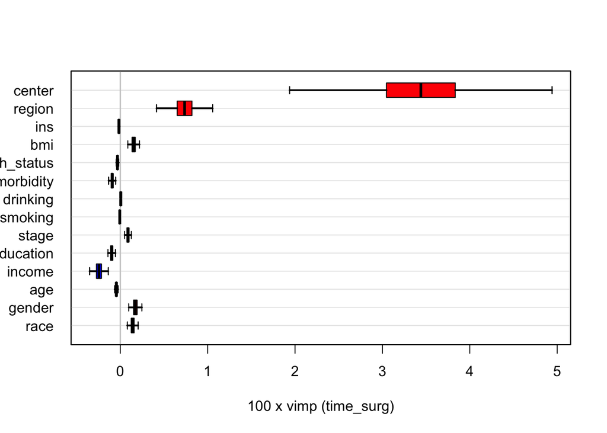

```r
plot(rf2.sub)
```

- center and region are significant factors in mediator model

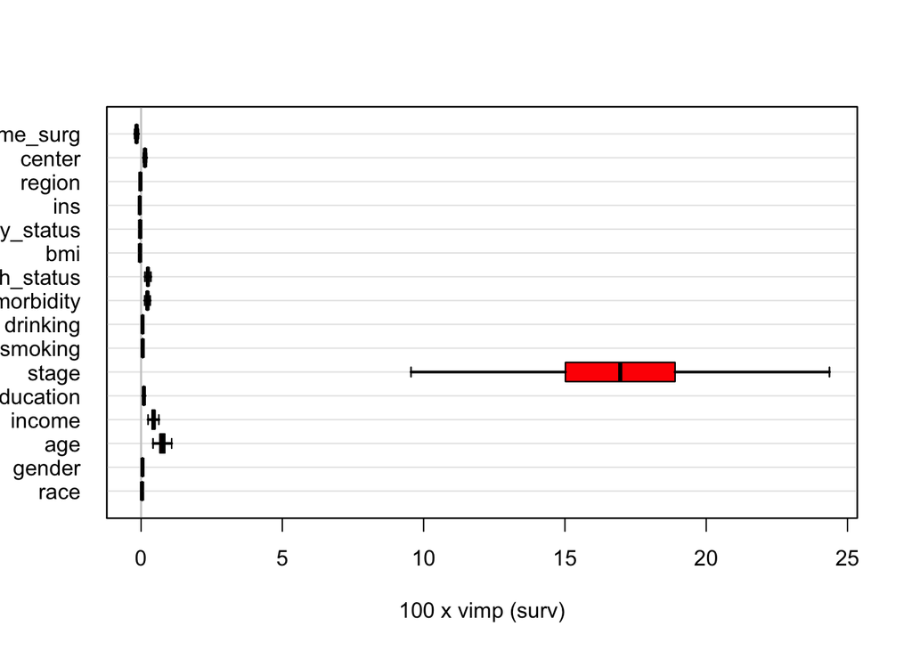

```r
plot(rf3.sub)
```

- cancer stage is still the only significant factor in outcome model

# Mediator Modeling

Based on the result from Random Forest analysis, we would investigate the potential inteaction with class membership in mediator model. For outcome model, we would go with the cancer stage at diagnosis.

## KM Curves for time to surgery

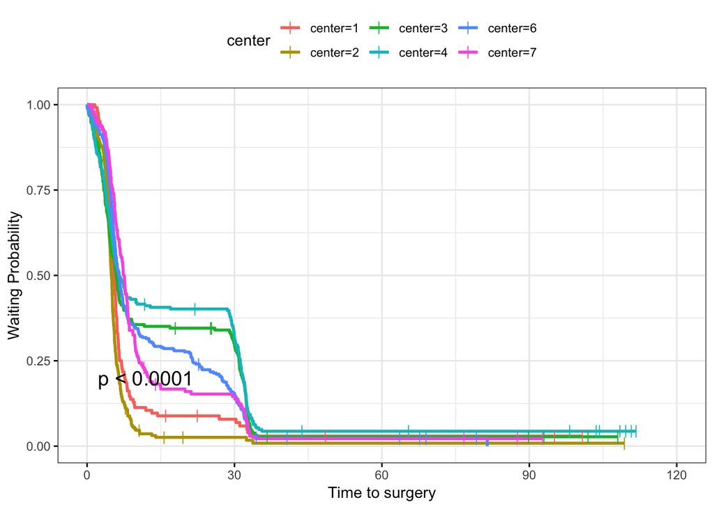

```r
# Only stratify by center
ggsurvplot(survfit(Surv(time_surg, surgery_status) ~ center, data = med.rf),censor.shape="|", censor.size = 3,pval = TRUE, conf.int=FALSE,legend.title="center",ggtheme = theme_bw(),ylab="Waiting Probability", xlab="Time to surgery")
```

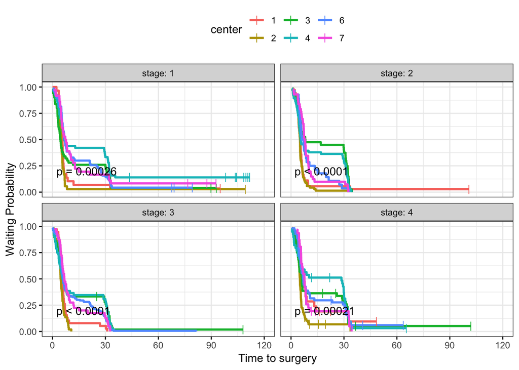

```r
# Test stage difference
ggsurvplot(survfit(Surv(time_surg, surgery_status) ~ center, data = med.rf),censor.shape="|", censor.size = 3,facet.by="stage",pval = TRUE, conf.int=FALSE,legend.title="center",ggtheme = theme_bw(),ylab="Waiting Probability", xlab="Time to surgery")
```

## AFT analysis

### Draw a histogram to show the distribution of center by stage and plot time to surgery by center

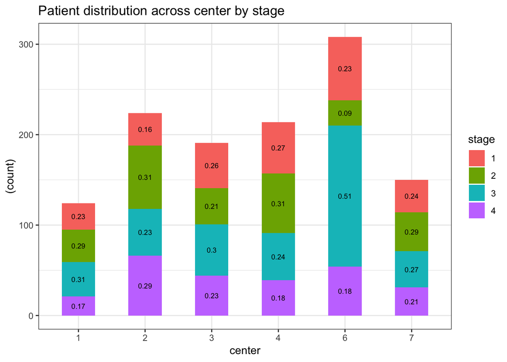

```r
# Create text labels
percentage = cancors_select %>%
  group_by(center,stage) %>%
  summarise(count=n()) %>%
  mutate(percent = count/sum(count),
         ypos=sum(count)-cumsum(count)+0.5*count)

center_stage <- ggplot(cancors_select,aes(center,group=stage)) +
  geom_bar(aes(fill=stage,y=(..count..)), width = 0.5) +
  theme(axis.text.x = element_text(angle=65, vjust=0.6)) +
  #geom_text(aes(y=(..count..),label=(..count..)),stat = "count")
  geom_text(data=percentage,aes(label=round(percent,2),y=ypos), colour="black", size=2.5)+theme_bw()+labs(title = "Patient distribution across center by stage" )
center_stage
```

The patinent distibution across stage is relatively proportioned in center1. From the KM curves, we also see a significant decrease in Time-to-surgery for patients from center1. Therefore, we chose center1 as the reference group to build the AFT model.

```r
cancors_select$center <- relevel( cancors_select$center, ref="1" )
```

### Part1 - Only adjust for stage

```r
# factor stage
med.fit.stage=survreg(Surv(time_surg,surgery_status)~center*stage,data=cancors_select,dist = "weibull")
summary(med.fit.stage)
```

```
##
## Call:
## survreg(formula = Surv(time_surg, surgery_status) ~ center *
##     stage, data = cancors_select, dist = "weibull")
##                  Value Std. Error     z       p
## (Intercept)     2.2996     0.1860 12.36 < 2e-16
## center2        -0.2164     0.2489 -0.87   0.385
## center3         0.3555     0.2334  1.52   0.128
## center4         1.0944     0.2325  4.71 2.5e-06
## center6         0.4218     0.2209  1.91   0.056
## center7         0.5651     0.2522  2.24   0.025
## stage2         -0.1124     0.2489 -0.45   0.651
## stage3         -0.2947     0.2446 -1.20   0.228
## stage4          0.2497     0.2967  0.84   0.400
## center2:stage2 -0.2564     0.3216 -0.80   0.425
## center3:stage2  0.3037     0.3258  0.93   0.351
## center4:stage2 -0.6123     0.3101 -1.97   0.048
## center6:stage2 -0.2977     0.3328 -0.89   0.371
## center7:stage2 -0.4686     0.3378 -1.39   0.165
## center2:stage3 -0.1934     0.3253 -0.59   0.552
## center3:stage3  0.3662     0.3120  1.17   0.241
## center4:stage3 -0.4791     0.3130 -1.53   0.126
## center6:stage3  0.0884     0.2835  0.31   0.755
## center7:stage3 -0.1567     0.3362 -0.47   0.641
## center2:stage4 -0.4876     0.3620 -1.35   0.178
## center3:stage4 -0.0673     0.3634 -0.19   0.853
## center4:stage4 -0.6383     0.3676 -1.74   0.082
## center6:stage4 -0.2504     0.3487 -0.72   0.473
## center7:stage4 -0.6936     0.3877 -1.79   0.074
## Log(scale)     -0.0187     0.0219 -0.85   0.394
##
## Scale= 0.981
##
## Weibull distribution
## Loglik(model)= -4033.6   Loglik(intercept only)= -4125.5
##  Chisq= 183.78 on 23 degrees of freedom, p= 4.8e-27
## Number of Newton-Raphson Iterations: 5
## n= 1211
```

```r
AIC(med.fit.stage) #8106.789
```

```
## [1] 8117.286
```

```r
# numeric stage
cancors_select$stage_n <- as.numeric(cancors_select$stage)
med.fit.stage_n=survreg(Surv(time_surg,surgery_status)~center*stage_n,data=cancors_select,dist = "weibull") #good
summary(med.fit.stage_n)
```

```
##
## Call:
## survreg(formula = Surv(time_surg, surgery_status) ~ center *
##     stage_n, data = cancors_select, dist = "weibull")
##                     Value Std. Error     z       p
## (Intercept)      2.140567   0.223536  9.58 < 2e-16
## center2         -0.220648   0.282128 -0.78   0.434
## center3          0.501591   0.288448  1.74   0.082
## center4          1.114484   0.274318  4.06 4.8e-05
## center6          0.479231   0.271175  1.77   0.077
## center7          0.651252   0.299937  2.17   0.030
## stage_n          0.032204   0.085126  0.38   0.705
## center2:stage_n -0.082015   0.104250 -0.79   0.431
## center3:stage_n  0.011509   0.108735  0.11   0.916
## center4:stage_n -0.173593   0.104602 -1.66   0.097
## center6:stage_n -0.048622   0.101061 -0.48   0.630
## center7:stage_n -0.155670   0.113080 -1.38   0.169
## Log(scale)       0.000676   0.021638  0.03   0.975
##
## Scale= 1
##
## Weibull distribution
## Loglik(model)= -4051.2   Loglik(intercept only)= -4125.5
##  Chisq= 148.62 on 11 degrees of freedom, p= 2.8e-26
## Number of Newton-Raphson Iterations: 5
## n= 1211
```

```r
AIC(med.fit.stage_n) #8118.676
```

```
## [1] 8128.446
```